# HW03: Multiple Regression

Austin Carango

December 9, 2016

# Abstract

The idea of this project is to perform multiple least squares regression on the Advertising data set. This dataset reports 200 observations of `Sales`, `TV`, `Radio`, and `Newspaper`. This data is freely available ass a CSV file at http://www-bcf.usc.edu/~gareth/ISL/Advertising.csv. The methods discused are based on Chapter 3: Linear Regression (from " *An Introduction to Statistical Learning*" by James et al), which is available at http://www-bcf.usc.edu/~gareth/ISL/ISLR%20First%20Printing.pdf.

# Introduction

Given a data set containing information pertaining to advertising budgets for three different media (TV, Radio, and Newspaper), how can we model sales of a product?

To answer this question, this report will discuss multiple linear regression. We will attempt to model sales in thousands of dollars as a function of three variables: `TV`, `Radio` and `Newspaper`. Because we are modelling this relationship via linear regression, we are inherently assuming that a linear relationship exists between our dependent variables and independent variable. We will run this regression, and then comment on its validity.

# Data

The data set utilized in this paper, `Advertising.csv`, contains 200 observations of 5 variables. Each observation corresponds to one firm, and 4 of the variables are of interest: `Sales`, `Radio`, `TV` and `Newspaper`. The variable `X` is an index.

This dataset is free to access online at the following url http://www-bcf.usc.edu/~gareth/ISL/Advertising.csv.

We will use all 4 variables of interest in this analysis. `Sales` refers to the sales of a particular product in thousands of dollars. `TV` refers to the firm’s TV advertising budget in thousands of dollars. `Radio` refers to the firm’s radio advertising mudget in thousands of dollars. `Newspaper` refers to the firm’s newspaper advertising budget in thousands of dollars.

In our analysis, we will treat `Sales` as the dependent variable and the other 3 variables of interest as the independent variables.

# Methodology

For this linear regression, we treat `Sales` as the response variable. This means `Sales` will depend on a function of some other variables. `TV`, `Newspaper` and `Radio` are the explanatory variables, meaning their values determine the value of `Sales` via a function. We use the simple linear model below to estimate the relationship between Sales and the three explanatory variables.

$$Sales = \beta_0 + \beta_1*TV + \beta_2*Radio + \beta_3*Newspaper$$

We have 4 beta coefficients, 3 of which determine the slope and one (beta0) which is the intercept.

In order to fit a line to this data we must minimize the squared error. In other words we must find a line that minimizes the squared error, error being the distance between actual and fitted values. We accomplish this by minimizing the expression below.

$$\sum_{i=1}^n (y_i - \beta_0 - \beta_1x_1i - \beta_2x_2i - \beta_3x_3i)^2$$

# Results

Performing simple least squares regression seperately for each of the three explanatory variables produces the following coefficient estimates:

```
## (Intercept)   Newspaper
##  12.3514071   0.0546931
```

```
## (Intercept)       Radio
##   9.3116381   0.2024958
```

```
## (Intercept)          TV
##  7.03259355  0.04753664
```

Performing multiple ordinary least squares with all three explanatory variables at once as described in the methodology section provides us with the following coefficients:

```
##  (Intercept)           TV        Radio    Newspaper
##  2.938889369  0.045764645  0.188530017 -0.001037493
```

Here is the correlation matrix:

```
##                   TV      Radio  Newspaper      Sales
## TV        1.00000000 0.05480866 0.05664787 0.78222442
## Radio     0.05480866 1.00000000 0.35410375 0.57622257
## Newspaper 0.05664787 0.35410375 1.00000000 0.22829903
## Sales     0.78222442 0.57622257 0.22829903 1.00000000
```

Using the functions created in `code/functions/regression-functions.R` we get the following values for RSS, TSS, R^2, F-statistic, and RSE:

[output not shown]

Here are some useful diagnostic plots for this regression as well:

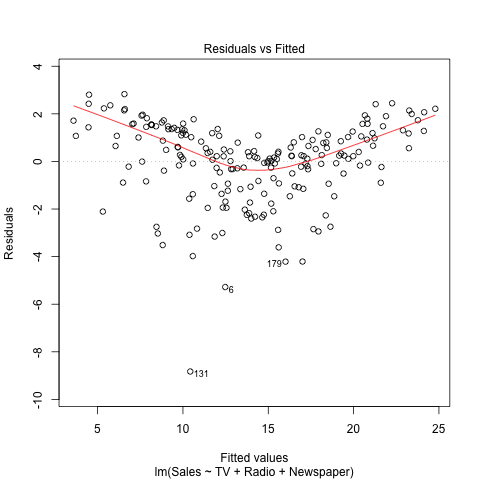

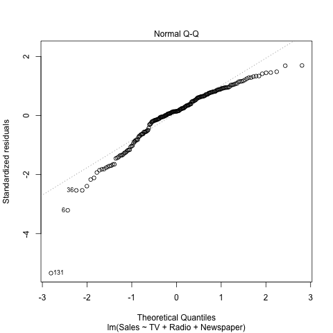

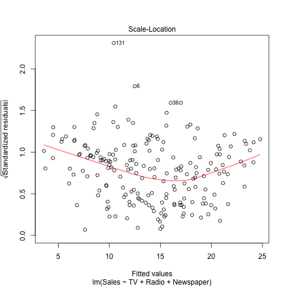

# Conclusions

In conclusion this model has its disadvantages, but is fairly accurate. `TV` at least seems to be a good predictor as it is correlated with `Sales` but not very correlated with any of the other predictors. The model fits the data very well, but we could drop either `Radio` or `Newspaper` and most likely get more reliable results by removing collinearity. Predictive accuracy could be improved by a model that accounts for the non-linearity we see in the residual vs fitted plot as well as evident heteroscedasticity in errors.